# 01. 02. Intro & 파이썬 기초

### NumPy : Numerical Python

- 빠르고 효율적인 다차원 배열 객체 ndarray
- 배열 원소를 다루거나 배열 간의 수학 계산을 수행하는 함수
- 디스크로부터 배열 기반의 데이터를 읽거나 쓸 수 있는 도구
- 선형대수 계산, 푸리에 변환, 난수 생성기
- 파이썬 확장과 C, C++ 코드에서 NumPy의 자료구조에 접근하고 계산 기능을 사용할 수 있도록 해주는 C API

### pandas

- 자동적으로 혹은 명시적으로 축의 이름에 따라 데이터를 정렬할 수 있는 자료구조, 이러한 자료구조는 잘못 정렬된 데이터에 의한 일반적인 오류를 예방하고 다양한 소스에서 가져온 다양한 방식으로 색인되어 있는 데이터를 다룰 수 있다.
- 통합된 시게열 기능
- 시계열 데이터와 비시게열 데이터를 함꼐 다룰 수 있는 통합 잘구조
- 메타데이터를 보존하는 산술 연산과 축약 연산
- 누락된 데이터를 유연하게 처리할 수 있는 기능
- 일반 데이터베이스(SQL)처럼 데이터를 합치고 관계 연산을 수행하는 기능

### matplotlib

### IPython & Jupyter

### SciPy

- `scipy.integrate` : 수치적분 루틴과 미분방정식 풀이법
- `scipy.linalg` : numpy.linalg에서 제공하는 것보다 더 확장된 선형대수 루틴과 매트릭스 분해
- `scipy.optimize` : 함수 최적하기와 방정식 근을 구하는 알고리즘
- `scipy.signal` : 시그널 프로세싱 도구
- `scipy.sparse` : 희소행렬과 희소선형 시스템 풀이법
- `scipy.special` : 감마함수처럼 흔히 사용되는 수학함수를 구현한 포트란 라이브러리인 SPECRUN 래퍼
- `scipy.stats` : 표준 연속/이산 확률 분포 (밀도함수, 샘플러, 연속분포함수)와 다양한 통계 테스트 그리고 좀 더 기술적인 통계 도구

### scikit-learn

- 분류 : SVM, KNN, RF, LR
- 회귀, LASSO, RIDGE
- 군집 : K-Means, Spectral Klustering
- 차원축소 : PCA, 특징 선택, 행렬 인수분해
- 모형선택 : 그리드 서치, 교차검증, 행렬
- 전처리 : 특징추출, 정규화

### statsmodels : 전통적인 통계와 계량경제학 알고리즘 포함

- 회귀모델 : 선형회귀, 일반화 선형 모델, 로버스트 선형 모델, 선형 혼합효과 모델 등
- 분산분석 : ANOVA
- 시계열분석, AR, ARMA, ARIMA, VAR 및 기타 모델
- 비모수 기법 : 커널밀도추정, 커널회귀
- 통계 모델 결과의 시각화

### 패키지 설치 : `pip install **package_name**`

### 경로 확인 : `os.getcwd()`

```python
print(os.getcwd())
```

```
C:\Users\이찬솔\Documents\Python_for_Data_Analysis
```

### 경로 작성 : `os.path.join()`

```python
os.path.join('Python_for_Data_Analysis', 'datasets')
```

```
'Python_for_Data_Analysis\\datasets'
```

### 경로 변경 : `os.chdir()`

```python
os.chdir('/' + os.path.join('Users','이찬솔','Documents','Python_for_Data_Analysis', 'datasets'))
print(os.getcwd())
```

```
C:\Users\이찬솔\Documents\Python_for_Data_Analysis\datasets
```

### 자기 관찰

- 변수나 함수의 앞이나 뒤에 '?'를 붙이면, 객체에 대한 일반 정보 출력
- '??'를 사용하면 가능한 경우 함수의 소스 코드도 출력

```python
b = [1, 2, 3]
b?
```

```python
print?
```

### 매직 명령어 : 파이썬 자체에는 존재하지 않는 특수 명령어, IPython에서만 사용 가능

| 명령어 | 설명 |
| --- | --- |
| %quickref | IPython의 빠른 도움말 |
| %magic | 모든 매직함수에 대한 상세 도움말 출력 |
| %debug | 최근 예외 트레이스백의 하단에서 대화형 디버거로 진입 |
| %hist | 명령어 입력 (그리고 선택적 출력) 히스토리 출력 |
| %pdb | 예외가 발생하면 자동으로 디버거 진입 |
| %paste | 클립보드에서 들여쓰기 된 채로 파이썬 코드 가져오기 |
| %cpaste | 실행할 파이썬 코드를 수동으로 붙여 넣을 수 있는 프롬프트 표시 |
| %reset | 대화형 네임스페이스에 정의된 모든 변수와 이름을 삭제 |
| %page 객체 | 객체를 pager를 통해 보기 좋게 출력 |
| %run 스크립트.py | IPython 내에서 파이썬 스크립트 실행 |
| %prun 상태문 | cProfile을 이용하여 상태문을 실행하고 프로파일 결과를 출력 |
| %time 상태문 | 상태문의 단일 실행 시간을 출력 |
| %timeit 상태문 | 상태문을 여러 차례 실행한 후 평균 실행 시간을 출력, 매우 짧은 시간 안에 끝나는 코드의 시간을 측정할 때 유용 |
| %who, %who_ls, %whos | 대화형 네임스페이스 내에 정의된 변수를 다양한 방법으로 표시 |
| %xdel 변수 | 변수를 제거하고 IPython 내부적으로 해당 객체에 대한 모든 참조를 제거 |

### `%run` : IPython에서 스크립트 파일 접근

- ipython_script_test.py

```
def f(x, y, z):
    return (x + y) / z

a = 5
b = 6
c = 7.5

result = f(a, b, c)
```

```python
%run -i ipython_script_test.py
```

```python
c
```

```
7.5
```

```python
result
```

```
1.4666666666666666
```

### `%load` : 스크립트 파일을 코드 셀로 불러옴 (매직함수)

```python
# %load ipython_script_test.py
Python 3.9.7 (tags/v3.9.7:1016ef3, Aug 30 2021, 20:19:38) [MSC v.1929 64 bit (AMD64)] on win32
Type "help", "copyright", "credits" or "license()" for more information.
>>> def f(x, y, z) :
	return (x + y) / z

>>> a = 5
>>> b = 6
>>> c = 7.5
>>> result = f(a, b, c)
>>> result
1.4666666666666666
>>>
```

### `%timeit` : 코드 실행 시간 측정

```python
import numpy as np
```

```python
a = np.random.randn(100, 100)
```

```python
%timeit np.dot(a, a)
```

```
259 µs ± 47.9 µs per loop (mean ± std. dev. of 7 runs, 1,000 loops each)
```

### matplotlib

```python
%matplotlib inline
```

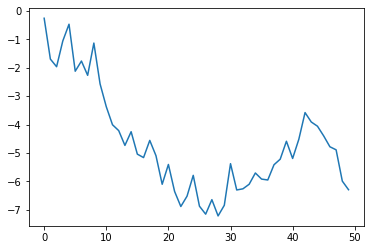

```python
import matplotlib.pyplot as plt
plt.plot(np.random.randn(50).cumsum())
```

### 파이썬 기본

### 함수와 객체 메서드 호출

- 파이썬의 거의 모든 객체는 함수를 포함 => 메서드
- 객체에 내부 데이터에 접근 가능

### 변수와 인자 전달

```python
a = [1, 2, 3]
```

```python
b = a
```

```python
a.append(4)
```

```python
b
```

```
[1, 2, 3, 4]
```

```python
a
```

```
[1, 2, 3, 4]
```

### 동적 참조와 강한 타입

### `type()` : 객체의 타입 확인

```python
a = 5
type(a)
```

```
int
```

```python
a = 'foo'
type(a)
```

```
str
```

```python
a = 4.5
b = 2
print('a is {0}, b is {1}'.format(type(a), type(b)))
a / b
```

```
a is <class 'float'>, b is <class 'int'>
```

```
2.25
```

### `isinstance(객체, 타입)` : 객체의 타입을 검사

```python
a = 5
isinstance(a, int)
```

```
True
```

### 속성과 메서드

### `getattr()` : 객체의 속성과 메서드 파악

```python
a = 'foo'
```

```python
getattr(a, 'split')
```

```
<function str.split(sep=None, maxsplit=-1)>
```

### 모듈 임포트

```
# some_module.py

PI = 3.14159

def f(x):
    return x + 2

def g(a, b):
    return a + b
```

```python
import some_module
result = some_module.f(5)
pi = some_module.PI
```

```python
from some_module import f, g, PI
result = g(5, PI)
```

### 가변, 불변 객체

- **리스트, 딕셔너리, NumPy 배열 또는 사용자 정의 클래스와 같은 대부분의 객체는 변경 가능**

```python
a_list = ['foo', 2, [4, 5]]
a_list
```

```
['foo', 2, [4, 5]]
```

```python
a_list[2]
```

```
[4, 5]
```

```python
a_list[2] = (3, 4)
a_list
```

```
['foo', 2, (3, 4)]
```

- **문자열이나 튜플은 변경 불가능**

```python
a_tuple = (3, 5, (4, 5))
```

```python
a_tuple[1] = 'four'
```

```
---------------------------------------------------------------------------
TypeError                                 Traceback (most recent call last)
Input In [83], in <cell line: 1>()
----> 1 a_tuple[1] = 'four'

TypeError: 'tuple' object does not support item assignment
```

### 자료 형태

| 자료형 | 설명 |
| --- | --- |
| None | 'null' |
| str | 문자열 자료형 (UTF-8) |
| bytes | Raw ASCII 바이트 |
| float | 부동소수점수, double형도 따로 존재 |
| bool | 참/거짓 |
| int | 부호가 있는 정수 |

#### 문자열

- 문자열은 일련의 문자 리스트 (튜플)로 취급

```python
s = 'python'
list(s)
```

```
['p', 'y', 't', 'h', 'o', 'n']
```

- 여러 줄에 걸친 문자열은 세 개의 따옴표로 둘러쌈

```python
c = """
a
b
"""
c
```

```
'\na\nb\n'
```

```python
c.count('\n')
```

```
3
```

- 두 문자열을 더하면 두 문자열을 이어붙인 새로운 문자열이 생성

```python
a = 'this is the first half'
b = ' and this is the second half'
a + b
```

```
'this is the first half and this is the second half'
```

#### - 문자열 format

- 포맷에 다라 문자열을 대체하여 새로운 문자열을 반환하는 format 메서드

```python
template = '{0:.2f} {1:s} are worth US${2:d}'
```

- {0:.2f} : 첫 번째 인사를 소수점 아래 2자리가지만 표시하는 부동소수점 형태로 출력하라는 의미
- {1:s} : 두 번째 인자가 문자열이라는 의미
- {2:d} : 세 번째 인자가 정수라는 의미

```python
template.format(4.5560, 'Argentine Pesos', 1)
```

[output not shown]

#### 바이트 / 유니코드

### `.encode(utf-8)` : 문자열 출력 형태 지정

```python
val = 'español'
val
```

```
'español'
```

```python
val_utf8 = val.encode('utf-8')
val_utf8
```

```
b'espa\xc3\xb1ol'
```

```python
val_utf8.decode('utf-8')
```

```
'español'
```

```python
val.encode('latin1')
```

```
b'espa\xf1ol'
```

```python
val.encode('utf-16')
```

```
b'\xff\xfee\x00s\x00p\x00a\x00\xf1\x00o\x00l\x00'
```

```python
val.encode('utf-16le')
```

```
b'e\x00s\x00p\x00a\x00\xf1\x00o\x00l\x00'
```

### 날짜와 시간

| %Y | 4자리 연도 |
| --- | --- |
| %y | 2자리 연도 |
| %m | 2자리 월 [01, 12] |
| %d | 2자리 일 [01, 31] |
| %H | 시간 (24시간 형식) [00, 23] |
| %I | 시간 (12시간 형식) [01, 12] |
| %M | 2자리 분 [00, 59] |
| %S | 초 [00, 61] (60, 61은 윤초) |
| %w | 정수로 나타낸 요일 [0, 6] |
| %U | 연중주차 [00, 53], 일요일을 그 주의 첫 번째 날로 간주하며, 그 해에서 첫 번째 일요일 앞에 있는 날은 0주차가 된다 |
| %W | 연중주차 [00, 53], 월요일을 그 주의 첫 번째 날로 간주하며, 그 해에서 첫 번째 월요일 앞에 있는 날은 0주차가 된다 |
| %z | UTC 시간대 오프셋을 +HHMM 또는 -HHMM으로 표현, 만약 시간대를 신경 쓰지 않는 다면 비워둠 |
| %F | %Y-%m-%d 형식에 대한 축약 |
| %D | %m/%d/%y 형식에 대한 축약 |

```python
from datetime import datetime, date, time
```

### `datetime` : datetime형 생성

```python
dt = datetime(2011, 10, 29, 20, 30, 21)
print(dt)
print(dt.day)
print(dt.minute)
```

```
2011-10-29 20:30:21
29
30
```

```python
dt.date()
```

```
datetime.date(2011, 10, 29)
```

```python
dt.time()
```

```
datetime.time(20, 30, 21)
```

### `.strftime` : datetime형을 문자열로 변환

```python
dt.strftime('%m/%d/%Y %H:%M')
```

```
'10/29/2011 20:30'
```

### `.strptime` : 문자열을 datetime형으로 변환

```python
datetime.strptime('20091031', '%Y%m%d')
```

```
datetime.datetime(2009, 10, 31, 0, 0)
```

### `.replace` : datetime형 수정

```python
dt.replace(minute = 0, second = 0)
```

```
datetime.datetime(2011, 10, 29, 20, 0)
```

### datetime.timedelta 객체 : datetime 객체의 차이

```python
dt2 = datetime(2011, 11, 15, 22, 30)
delta = dt2 - dt
print(delta)
print(type(delta))
```

```
17 days, 1:59:39
<class 'datetime.timedelta'>
```

### 조건문

### `if`, `elif`, `else`

```
if x < 0:
    print('It's negative')
elif x == 0:
    print('Equal to zero')
elif 0 < x < 5:
    print('Positive but smaller than 5')
else:
    print('Positive and larger than or equal to 5')
```

### 반복문

### `for`, `break`

```python
# 5를 만날 때 까지 모든 원소를 더함
sequence = [1, 2, 0, 4, 6, 5, 2, 1]

total_until_5 = 0
for value in sequence:
    if value == 5:
        break
    total_until_5 += value

print(total_until_5)
```

```
13
```

### `while`, `break`

- 해당 조건이 FALSE가 되거나 break문을 사용할 대 까지 반복 수행

```
x = 256
total = 0
while x > 0:
    if total > 500:
        break
    total += x
    x = x // 2
```

### `pass`

```
if x < 0:
    print('negative!')
    elif x == 0:
    # TODO: put something smart here
    pass
else:
    print('positive!')
```

### `range(start , end, step)` : 연속된 정수를 넘겨주는 이터레이터를 반환

- **end값의 바로 이전 정수까지 반환**
- `start` : 시작값
- `end` : 종결값
- `step` : 간격

```python
print(range(0, 10))
print(list(range(0, 10)))
print(list(range(0, 20, 2)))
```

```
range(0, 10)
[0, 1, 2, 3, 4, 5, 6, 7, 8, 9]
[0, 2, 4, 6, 8, 10, 12, 14, 16, 18]
```

```python
seq = [1, 2, 3, 4]
for i in range(len(seq)):
    val = seq[i]
print(val)
```

```
4
```

```python
sum = 0
for i in range(10000) :
    if i%3 == 0 or i % 5 == 0 :
        sum += i
print(sum)
```

```
23331668
```

### 삼항 표현식 : if-else문을 한 줄로 표현

```python
x = 5
'Non-negative' if x >= 0 else 'Negative'
```

```
'Non-negative'
```